# Translation Hoang - Kostrzewski

Initial case study to develop methodology - translation and comparisong of Hoang et al (human) and Kostrzewski et al (MPS)

# Load libraries and functions

Additional libraries are called internally

```r
library(decoupleR)
library(OmnipathR)
library(caret)
library(ropls)
library(matrixStats)
dir_root <- ""



source(paste0(dir_root,"utils/plotting_functions.R"))
source(paste0(dir_root,"modeling/functions_translation_jose.R"))
source(paste0(dir_root,"utils/wrapper_DECOUPLER.R"))
```

```
[2024-04-25 17:04:28] [SUCCESS] [OmnipathR] Downloaded 64958 interactions.
[2024-04-25 17:04:29] [SUCCESS] [OmnipathR] Downloaded 232 interactions.
[2024-04-25 17:04:31] [SUCCESS] [OmnipathR] Loaded 700239 annotation records from cache.
```

```r
options(expressions = 5e5)
set.seed(123)
dir_data <- paste0(dir_root,"data/")
```

# Load datasets

Focusing on Hoang et al and Kostrzewski et al. Pre-processing is intersecting features, log CPM normalization centering, and PCA for visualization although PCA is not crucial

```r
dataset_names <- c("Hoang", "Kostrzewski", "Wang", "Feaver") #, "Feaver", "Wang", "Nilsson", "Govaere") #, "Wang", "Govaere")
ref_dataset <- "Hoang"
target_dataset <- "Kostrzewski"
# Load
data_list <- load_datasets(dataset_names, dir_data = dir_data)
```

```
[1] "Loading file: data/GSE13090_Hoang_dataset.RData"
[1] "Loading file: data/GSE168285_Kostrzewski_dataset.RData"
[1] "Loading file: data/GSE166256_Wang_dataset.RData"
[1] "Loading file: data/GSE89063_Feaver_dataset.RData"
```

```r
# Run PCA
tmp <- process_datasets(data_list, filter_variance = F)
data_list <- tmp$data_list
plt_list <- tmp$plt_list
# Define matrices of interest
# Yh <- data_list$Hoang$metadata$nafld_activity_score #data_list$Hoang$metadata$Fibrosis_stage#
Yh <- as.matrix(data_list$Hoang$metadata  %>% select(nafld_activity_score,Fibrosis_stage)) #keep both Fibrosis and NAS
colnames(Yh) <- c('NAS','fibrosis')
Xh <- data_list[[ref_dataset]]$data_center %>% t()
Xm <- data_list[[target_dataset]]$data_center %>% t()
# Get Wm as the PC space of the MPS data when averaging tech replicates to capture variance due to experimental factors
Wm <- data_list[[target_dataset]]$Wm_group %>% as.matrix()
```

# Build PLSR model

```r
### Load idx for CV splits
#idx_train_CV <- createFolds(Yh, k = 10, returnTrain = T)
#save(idx_train_CV, file = paste0(dir_data,"idx_train_CV_NAFLD.RData"))
load(paste0(dir_data,"idx_train_CV_NAFLD.RData"))

### Train PLSR - lots of internal CV, so it is slow - try to make parallel
#plsr_mod <- train_plsr(Xh, Yh, idx_train_CV)
#save(plsr_mod, file = paste0(dir_data,"temp_PLSR_mod.RData"))
# Model coefficients (including intercept) - TO DO: get rid of intercept by centering Y
#Wh <- plsr_mod$Wf
#load(file = paste0(dir_data,"temp_PLSR_mod.RData"))
# Model coefficients (including intercept) - TO DO: get rid of intercept by centering Y
#Wh <- plsr_mod$Wf

#### Skipping for now to move quickly
plsr_mod <- opls(x = Xh,
                 y = Yh,
               predI = 9,
                crossvalI = 1,
               scaleC = "center",
                fig.pdfC = "none",
                 info.txtC = "none")
Wh <- matrix(data = 0, ncol = ncol(plsr_mod@weightMN), nrow = ncol(Xh))
rownames(Wh) <- colnames(Xh)
colnames(Wh) <- colnames(plsr_mod@weightMN)
for (ii in 1:nrow(plsr_mod@weightMN)){
  Wh[rownames(plsr_mod@weightMN)[ii], ] <- plsr_mod@weightMN[ii,]
}
######
# Get regression coefficients
Bh <- matrix(lm(Yh ~ Xh %*% Wh) %>% coef(), ncol = 2)

# Get variances in LVs
plsr_var_plsr <- colVars(Xh %*% Wh)
plsr_per_var_plsr <- round(100*plsr_var_plsr/sum(data_list$Hoang$pca$sdev^2),2)

### Visualize
# Plot predictions in full training
yhat <- cbind(1, Xh %*% Wh) %*% Bh
plt_PLSR_mod_nas <- plot_scatter(x = Yh[,1], y = yhat[,1],
                                        xlab = "NAS Measured", ylab = "NAS Predicted", xjitter = T) +
                            geom_abline(slope = 1, intercept = 0, color = "indianred",
                                        linetype="dotted", size = size_line)

plt_PLSR_mod_fibrosis <- plot_scatter(x = Yh[,2], y = yhat[,2],
                                        xlab = "Fibrosis Measured", ylab = "Fibrosis Predicted", xjitter = T) +
                            geom_abline(slope = 1, intercept = 0, color = "indianred",
                                        linetype="dotted", size = size_line)




plt_PLSR_score_NAS <- plot_scatter(x = Xh %*% Wh[,1], y = Xh %*% Wh[,2],
                         xlab = paste0("LV1 (", plsr_per_var_plsr[1],"%)"),
                         ylab = paste0("LV2 (", plsr_per_var_plsr[2],"%)"),
                         args_extra = data.frame(color = Yh[,1]),
                         aes_extra = aes(color = color)) +
            scale_color_viridis_c() + labs(color = "NAS")

plt_PLSR_score_FIBROSIS <- plot_scatter(x = Xh %*% Wh[,1], y = Xh %*% Wh[,2],
                         xlab = paste0("LV1 (", plsr_per_var_plsr[1],"%)"),
                         ylab = paste0("LV2 (", plsr_per_var_plsr[2],"%)"),
                         args_extra = data.frame(color = Yh[,2]),
                         aes_extra = aes(color = color)) +
            scale_color_viridis_c() + labs(color = "Fibrosis")
```

# Check information preservation

See how model prediction worsens when we use the MPS space

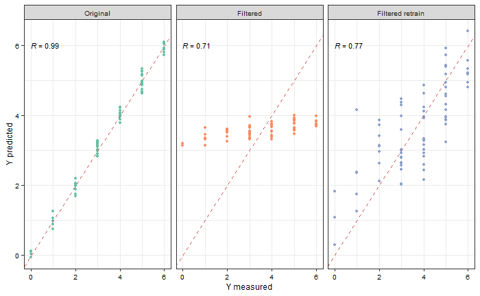

```r
# Get plots - TO DO: Extend statistics with CV
plt_info_loss <- get_info_loss(Xh, Yh, Wh, Wm, Bh)
print(plt_info_loss[[1]])
```

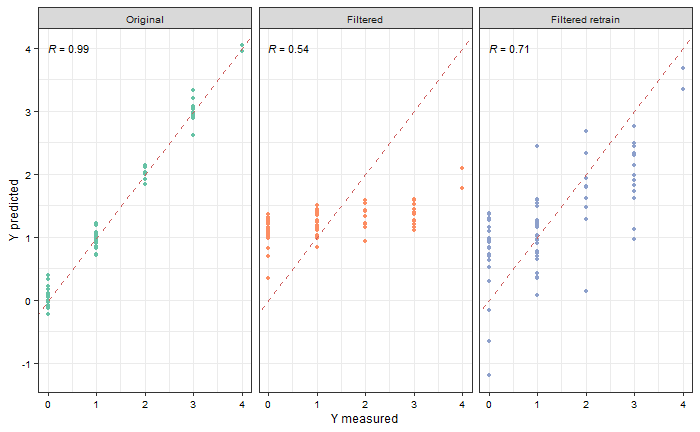

```r
print(plt_info_loss[[2]])
```

# Find translatable latent variables

Find latent variables that are combinations of MPS PCs (i.e. vectors of non-zero variance) that are the most translatable

```r
Wm_new <- get_translatable_LV(Xh, Yh, Wh, Wm, Bh, find_extra = FALSE)
```

```
[1] "Finding translatable LVs in data"
[1] "Finding LV #1..."
[1] "Done!"
[1] "Finding new vector basis..."
[1] "Done!"
[1] "Finding LV #2..."
[1] "Done!"
[1] "Finding new vector basis..."
[1] "Done!"
[1] "Finding LV #3..."
[1] "Done!"
[1] "Finding new vector basis..."
[1] "Done!"
```

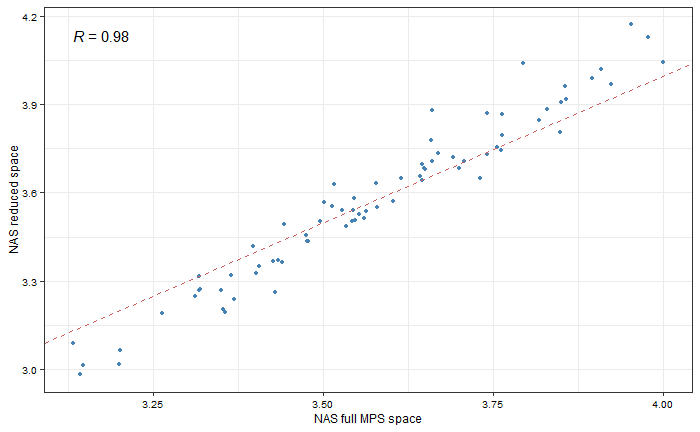

```r
Wm_new <- Wm_new$Wm_new
colnames(Wm_new) <- paste0(target_dataset,"_LVdata",1:ncol(Wm_new))

# Plot Yh predicted with this reduced space vs the larger MPS space
Ypred1 <- cbind(1, Xh %*% Wm %*% t(Wm) %*% Wh) %*% Bh
Ypred2 <- cbind(1, Xh %*% Wm_new %*% t(Wm_new) %*% Wh) %*% Bh

plt_new_basis_nas <- plot_scatter(x = Ypred1[,1], y = Ypred2[,1],
                              xlab = "NAS full MPS space", ylab = "NAS reduced space") +
                  geom_abline(intercept = 0, slope = 1, linetype = 2, color = "indianred") +
                  stat_cor(aes(label = after_stat(r.label)), show.legend = F, color = "black")
print(plt_new_basis_nas)
```

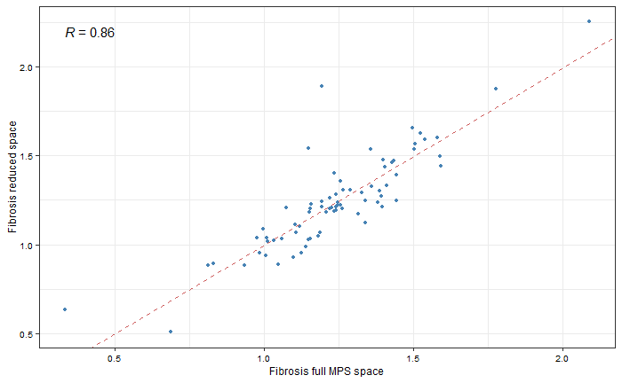

```r
plt_new_basis_fibrosis <- plot_scatter(x = Ypred1[,2], y = Ypred2[,2],
                              xlab = "Fibrosis full MPS space", ylab = "Fibrosis reduced space") +
                  geom_abline(intercept = 0, slope = 1, linetype = 2, color = "indianred") +
                  stat_cor(aes(label = after_stat(r.label)), show.legend = F, color = "black")
print(plt_new_basis_fibrosis)
```

```r
# Find experimental factors that contribute to the new latent variable (to do: Wrap in functions)

df_exp <- data.frame(data_list[[target_dataset]]$metadata[,data_list[[target_dataset]]$exp_factors])
colnames(df_exp) <- data_list[[target_dataset]]$exp_factors
aov(y ~., data = data.frame(y = as.numeric(Xm %*% Wm_new[,1]),
                            df_exp)) %>% summary()
```

```
             Df Sum Sq Mean Sq F value   Pr(>F)
NPC           1    495     495   5.126 0.024821 *
Background    1   1579    1579  16.331 8.01e-05 ***
TGF           1  44813   44813 463.588  < 2e-16 ***
LPS           1      1       1   0.010 0.921977
Cholesterol   1   3430    3430  35.481 1.42e-08 ***
Fructose      1   1358    1358  14.044 0.000244 ***
Residuals   172  16626      97
---
Signif. codes:  0 ‘***’ 0.001 ‘**’ 0.01 ‘*’ 0.05 ‘.’ 0.1 ‘ ’ 1
```

```r
# Project MPS data on this space
plt_new_basis_project <- data.frame(y = as.numeric(Xm %*% Wm_new[,1]),
                                    data_list[[target_dataset]]$metadata) %>%
                          ggplot(aes(x = y, y = reorder(Combination_name, y), fill = TGF)) +
                            geom_boxplot(size = size_col) +
                            facet_grid(rows = vars(NPC), cols = vars(Background)) +
                            labs(x = "LV1 score", y = NULL)

plt_new_basis_project <- add_theme(plt_new_basis_project) + scale_fill_brewer(palette = color_palette)
```